# Untitled

## github link

https://github.com/SONG-Yunqi/STATS-506-HW6

## Question 1

```r
library(Rcpp)
library(e1071)
```

```r
cppFunction('
  double C_moment(NumericVector x, int k) {
    int n = x.size();
    if (n == 0) return NA_REAL;

    double m1 = 0.0;
    for (int i = 0; i < n; i++) {
      m1 += x[i];
    }
    m1 /= n;

    double m2 = 0.0;
    for (int i = 0; i < n; i++) {
      m2 += pow(x[i] - m1, k);
    }

    return m2 / n;
  }
')
```

We generate a sample and compare the results of our C_moment function and e1071::moment.

```r
set.seed(42)
x = rnorm(1000,2,2.5)
k = 5

moment(x,k,center = TRUE)
```

```
[1] 26.64022
```

```r
C_moment(x,k)
```

```
[1] 26.64022
```

We see the results are equal.

## Question 2

### (a)

```r
library(parallel)
source('waldCI.R')
```

```r
setClass("bootstrapWaldCI",
         contains = "waldCI",
         slots = c(f = "function",
                   data = "ANY",
                   reps = "numeric",
                   compute = "character"))

setGeneric("rebootstrap", function(object) {
  standardGeneric("rebootstrap")
})
```

```
[1] "rebootstrap"
```

```r
makeBootstrapCI = function(f, data, reps, level = 0.95, compute = "serial") {

  n = nrow(data)
  boot_values = numeric(reps)

  if (compute == "serial") {

    boot_values = sapply(1:reps, function(i) {
      idx = sample.int(n, n, replace = TRUE)
      boot_data = data[idx, , drop = FALSE]
      return(f(boot_data))
    })

  } else if (compute == "parallel") {

    num_cores = max(1, detectCores() - 1)
    cl = makeCluster(num_cores)
    on.exit(stopCluster(cl))

    clusterExport(cl, varlist = c("data", "f", "n"), envir = environment())

    boot_values = parSapply(cl, 1:reps, function(i) {
      idx = sample.int(n, n, replace = TRUE)
      boot_data = data[idx, , drop = FALSE]
      return(f(boot_data))
    })

  } else {
    stop("compute argument must be 'serial' or 'parallel'")
  }

  original_est = f(data)
  boot_se = sd(boot_values)

  new("bootstrapWaldCI",
      mean = original_est,
      sterr = boot_se,
      level = level,
      f = f,
      data = data,
      reps = reps,
      compute = compute)
}

setMethod("rebootstrap", "bootstrapWaldCI", function(object) {
  makeBootstrapCI(f = object@f,
                  data = object@data,
                  reps = object@reps,
                  level = object@level,
                  compute = object@compute)
})
```

### (b)

```r
ci1 <- makeBootstrapCI(function(x) mean(x$y),
                       ggplot2::diamonds,
                       reps = 1000)
ci1
```

```
95% CI: (5.724705, 5.744347)
```

```r
rebootstrap(ci1)
```

```
95% CI: (5.724949, 5.744103)
```

### (c)

```r
dispCoef = function(data) {
  fit = lm(mpg ~ cyl + disp + wt, data = data)
  return(coef(fit)["disp"])
}

t_start = Sys.time()
ci2 = makeBootstrapCI(f = dispCoef,
                      data = mtcars,
                      reps = 1000,
                      compute = "serial")
t_end = Sys.time()
print(ci2)
```

```
95% CI: (-0.01116012, 0.02610597)
```

```r
cat("Serial Time:", t_end - t_start, "\n")
```

```
Serial Time: 0.4301159
```

```r
ci2_new = rebootstrap(ci2)
print(ci2_new)
```

```
95% CI: (-0.01187753, 0.02682338)
```

```r
t_start = Sys.time()
ci2_para = makeBootstrapCI(f = dispCoef,
                           data = mtcars,
                           reps = 1000,
                           compute = "parallel")
t_end = Sys.time()
cat("Parallel Time:", t_end - t_start, "\n")
```

```
Parallel Time: 0.34816
```

## Question 3

### (a)

We first load the data.

```r
load(file = 'data.RData')
head(df)
```

```
       age country device_type employment_status course_difficulty prior_gpa
1 25.51619      US       phone           student             intro  3.013935
2 28.15858   Other      tablet           student      intermediate  2.722186
3 42.46967   Other     desktop           student             intro  3.857653
4 30.56407   India       phone         full_time             intro  2.713303
5 31.03430      US     desktop         part_time             intro  2.519718
6 43.72052 Germany      laptop         full_time      intermediate  2.578767
  weekly_study_hours forum_posts quiz_attempts session_minutes
1           5.329206           1             3        255.5998
2           8.461048           3             2        395.2458
3           9.809836           3             1        447.4658
4           5.598963           0             7        268.2975
5           6.709972           1             1        469.9135
6           3.801268           0             2        279.8875
  paid_subscription final_score completed_course early_dropout time_to_dropout
1                 0    55.48092                0             1        5.952134
2                 1    53.62279                1             0              NA
3                 0    75.07775                0             0              NA
4                 0    63.92979                1             0              NA
5                 1    71.41279                0             0              NA
6                 1    55.01217                0             0              NA
```

```r
table(df['country'])
```

```
country
  Germany     India Lithuania   Nigeria     Other        US
   370313    615676     12290     24676   1235989    741056
```

```r
library(tidyverse)
# standardize the data
df_std = df %>%
  group_by(country) %>%
  mutate(
    prior_gpa_z = as.numeric(scale(prior_gpa)),
    forum_posts_z = as.numeric(scale(forum_posts)),
    quiz_attempts_z = as.numeric(scale(quiz_attempts))
  ) %>%
  ungroup()
```

Fit models.

```r
library(lme4)
df_list = split(df_std, df_std$country)

models = vector("list", length(df_list))
times  = vector("list", length(df_list))
coef_forum = c()

for (i in seq_along(df_list)){
  d = df_list[[i]]
  t = system.time({
    model = glmer(
      completed_course ~ prior_gpa_z + forum_posts_z + quiz_attempts_z + (1 | device_type),
      data = d,
      family = binomial,
      control = glmerControl(optimizer = "bobyqa",
                             optCtrl   = list(maxfun = 2e5))
    )}
  )

  models[[i]] = model
  times[[i]]  = t
  cm = summary(model)$coefficients
  coef_forum = append(coef_forum,cm["forum_posts_z", "Estimate"])
}
```

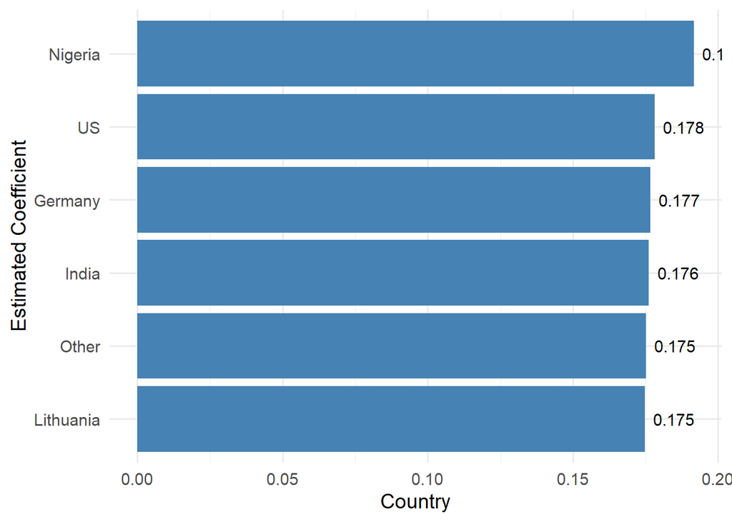

```r
coef_df = data.frame(country = names(df_list), value = coef_forum)

ggplot(coef_df, aes(x = reorder(country, value), y = value)) +
  xlab('Estimated Coefficient') +
  ylab('Country') +
  geom_col(fill = "steelblue") +
  geom_text(aes(label = round(value, 3)),
            hjust = ifelse(coef_df$value >= 0, -0.2, 1.2),
            size = 4) +
  coord_flip() +
  theme_minimal(base_size = 14)
```

Report the running time.

```r
names(times) = names(df_list)
times
```

```
$Germany
   user  system elapsed
  31.96    0.20   32.19

$India
   user  system elapsed
  48.03    0.30   48.30

$Lithuania
   user  system elapsed
   0.99    0.01    1.00

$Nigeria
   user  system elapsed
   2.17    0.03    2.20

$Other
   user  system elapsed
  95.10    9.67  104.83

$US
   user  system elapsed
  60.47    0.48   60.95
```

### (b)

```r
library(parallel)

n_cores = min(detectCores() - 1, length(df_list))
cl = makeCluster(n_cores)

clusterExport(cl, varlist = c("df_list"))
clusterEvalQ(cl, { library(lme4) })
```

[output not shown]

```r
total_time = system.time({
  results = parLapply(cl, seq_along(df_list), function(i) {
    d = df_list[[i]]
    model = glmer(
      completed_course ~ prior_gpa_z + forum_posts_z + quiz_attempts_z + (1 | device_type),
      data = d,
      family = binomial,
      control = glmerControl(optimizer = "bobyqa",
                             optCtrl   = list(maxfun = 2e5))
    )

    return(model)
  })
})

stopCluster(cl)
```

```r
total_time
```

```
   user  system elapsed
   1.25    1.07  111.56
```

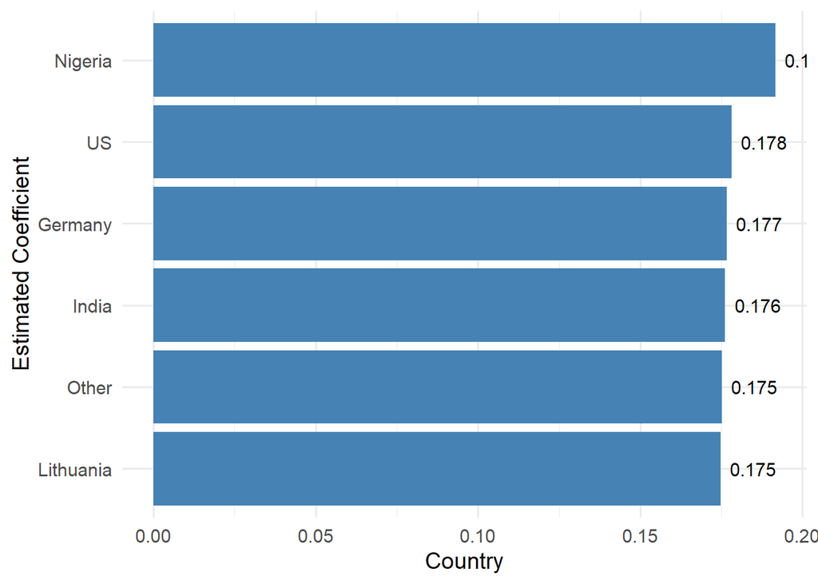

```r
coef_forum1 = c()

for (i in 1:length(df_list)){
  model = results[[i]]
  cm = summary(model)$coefficients
  coef_forum1 = append(coef_forum1,cm["forum_posts_z", "Estimate"])
}

coef_df1 = data.frame(country = names(df_list), value = coef_forum1)

ggplot(coef_df1, aes(x = reorder(country, value), y = value)) +
  xlab('Estimated Coefficient') +
  ylab('Country') +
  geom_col(fill = "steelblue") +
  geom_text(aes(label = round(value, 3)),
            hjust = ifelse(coef_df$value >= 0, -0.2, 1.2),
            size = 4) +
  coord_flip() +
  theme_minimal(base_size = 14)
```

## Question 4

### (a)

```r
library(data.table)
library(stringr)

matches <- fread(
  "atp_matches_2019.txt",
  sep   = ",",
  quote = "",
  fill  = TRUE
)

head(matches)
```

```
   tourney_id tourney_name surface draw_size tourney_level tourney_date
       <char>       <char>  <char>     <int>        <char>        <int>
1:  2019-M020     Brisbane    Hard        32             A     20181231
2:  2019-M020     Brisbane    Hard        32             A     20181231
3:  2019-M020     Brisbane    Hard        32             A     20181231
4:  2019-M020     Brisbane    Hard        32             A     20181231
5:  2019-M020     Brisbane    Hard        32             A     20181231
6:  2019-M020     Brisbane    Hard        32             A     20181231
   match_num winner_id winner_seed winner_entry        winner_name winner_hand
       <int>     <int>       <int>       <char>             <char>      <char>
1:       300    105453           2                   Kei Nishikori           R
2:       299    106421           4                 Daniil Medvedev           R
3:       298    105453           2                   Kei Nishikori           R
4:       297    104542          NA           PR Jo-Wilfried Tsonga           R
5:       296    106421           4                 Daniil Medvedev           R
```

[output cut: 49 more lines]

Here I just assume all matches take place in 2018 are parts of tourney ending in 2019. In addition, I handle the special case of David cup.

```r
total_tournament_count = matches[
  , tourney_name := str_replace(tourney_name, "Davis.*", "Davis Cup")
][
  , .(total_tournament_count = uniqueN(tourney_name))
]

total_tournament_count
```

```
   total_tournament_count
                    <int>
1:                     69
```

There are 69 tournaments in 2019.

### (b)

For each tournament, the last match was the one with biggest match_num. So the tournament winner should be the winner of the last match.

```r
t2 = matches[
  matches[, .I[which.max(match_num)], by = tourney_id]$V1,
  .(tourney_id, winner_name)
][
  , .(winning_count = .N), by = winner_name
][
  winning_count > 1
][
  order(-winning_count)
]

nrow(t2)
```

```
[1] 17
```

```r
t2
```

```
           winner_name winning_count
                <char>         <int>
 1:       Rafael Nadal             9
 2:     Novak Djokovic             8
 3:     Alex De Minaur             6
 4:      Dominic Thiem             5
 5:    Daniil Medvedev             4
 6:      Roger Federer             4
 7:     Cristian Garin             4
 8:   Denis Shapovalov             4
 9: Stefanos Tsitsipas             3
10:        Robin Haase             3
11: Jo-Wilfried Tsonga             2
12:       Nick Kyrgios             2
13:       Benoit Paire             2
14:  Matteo Berrettini             2
15:       Taylor Fritz             2
16:  Diego Schwartzman             2
17:    Karen Khachanov             2
```

There are 17 players who won more than 1 tournament. The most winning player won 9 tournaments.

### (c)

We use a one-side paired t-test to solve this question. For each match, we will compute diff = w_ace - l_ace. Then we will test whether the mean of diff is 0. If a match has missing w_ace or l_ace, we just remove that match.

```r
t3 = matches[
  !is.na(w_ace) & !is.na(l_ace),
  {
    diff = w_ace - l_ace
    .(t = sqrt(.N) * mean(diff) / sd(diff))
  }
]

t3
```

```
          t
      <num>
1: 12.37302
```

We see the observed t-statistic is greater than 1.64. Then we have strong evidence that the winner ace is greater than the loser ace.

### (d)

```r
t4_long = melt(
  matches[, .(win = winner_name, lose = loser_name)],
  measure.vars  = c("win", "lose"),
  variable.name = "result",
  value.name    = "name"
)

t4 = t4_long[
  , .(
    win_cnt   = sum(result == "win"),
    lose_cnt  = sum(result == "lose"),
    total_cnt = .N,
    win_rate  = sum(result == "win") / .N
  ),
  by = name
][
  total_cnt >= 5
]

t4 = t4[win_rate == max(win_rate)]

t4
```

```
           name win_cnt lose_cnt total_cnt  win_rate
         <char>   <int>    <int>     <int>     <num>
1: Rafael Nadal      60        9        69 0.8695652
```

Rafael Nadal has the highest winning rate.